# Drug Use Disorders in European Countries

## 1.0 Introduction

Excessive consumption of drugs can lead to untold effects to our health, both physical and mental. This can affect how we think and relate with others. It can affect people from all walks of life and all age groups.

The objective of this study is to understand the entire landscape and effect of drug use disorders across different age groups and genders, with an aim find trends and patterns that will aid health practictioners and policy makers to take appropriate actions to solve issues of drug use disorders.

The scope of this study covers the prevalence and mortality of different drug use disorders in European Countries for the period 1997 to 2017. We will be searching for overall trends and patterns in age distributions, gender as well as among countries in Europe.

Datasets for this study was obtained from the Institute for Health Metrics and Evaluation (IHME) which provides comprehensive estimates on global population health. The specific datasets where obtained using the query tool from the Global Burden of Disease Study 2017 (http://ghdx.healthdata.org/gbd-results-tool). Supplementary datasets were also obtained from the world bank open data portal(https://data.worldbank.org/)

Finally, before we begin our analysis, it is imperative to define some terms that will be useful for understanding this study

1. Prevalence: Prevalence is a concept referring to the number of cases of a disease that are present in a population at a given time.
2. Mortality: Mortality is a concept referring to the number of deaths from a disease that are occurs in a population at a given time. In the context of this study, it relates to death due to drug overdose.
3. Opioids: Opioids are psychoactive substances derived from the opium poppy, or their synthetic analogues. Examples are morphine, codeine and heroin.

```python
# import relevant libraries
import pandas as pd
import numpy as np
import matplotlib.pyplot as plt
import plotly
import plotly.graph_objects as go
import chart_studio.plotly as py
from plotly.subplots import make_subplots
py.sign_in('eserichard', 'TgllhSOe3mrFKrkjZe18')

import warnings
warnings.filterwarnings('ignore')
```

```python
# Import datasets
# Import drug use disorders prevalence from 1997 to 2017
prevalence = pd.read_csv("drug_use_disorders_prevalencee.csv", header=0)

# Import substance use disorder mortality from 1997 to 2017
mortality = pd.read_csv("drug_use_disorders_deaths.csv", header=0)

# Import population figures for all eurpoean countries (at 2017)
all_eu_countries = pd.read_csv('population_eu_countries.csv', header=0)
```

```python
# peek into the first five rows of the drug use disorders prevalence data frame
prevalence.head()
```

|  | measure | location | sex | age | cause | metric | year | val | upper | lower |
| --- | --- | --- | --- | --- | --- | --- | --- | --- | --- | --- |
| 0 | Prevalence | Spain | Male | 5-14 years | Opioid use disorders | Number | 1998 | 0.000000 | 0.00000 | 0.00000 |
| 1 | Prevalence | Spain | Female | 5-14 years | Opioid use disorders | Number | 1998 | 0.000000 | 0.00000 | 0.00000 |
| 2 | Prevalence | Spain | Male | 15-49 years | Opioid use disorders | Number | 1998 | 72783.354090 | 81607.26719 | 63642.20871 |
| 3 | Prevalence | Spain | Female | 15-49 years | Opioid use disorders | Number | 1998 | 25565.807750 | 29975.26332 | 21566.23296 |
| 4 | Prevalence | Spain | Male | 50-69 years | Opioid use disorders | Number | 1998 | 7513.599686 | 9526.99645 | 5822.46700 |

# 2.0 Data Cleaning

Before we begin our analysis, we shall conduct some cleaning steps to ensure our datasets are in the right format for analysis

```python
# Remove irrevalant columns from dataframe
# Create list with prevalence and mortality dataframes
all_disorders = [prevalence, mortality]

# Create array with columns to be dropped
drop = ['measure', 'metric', 'upper', 'lower']

# Drop columns across different dataframes
for df in all_disorders:
    df.drop(drop, axis=1, inplace=True)
```

```python
# peek into the first five rows of the drug use disorders prevalence data frame
prevalence.head()
```

|  | location | sex | age | cause | year | val |
| --- | --- | --- | --- | --- | --- | --- |
| 0 | Spain | Male | 5-14 years | Opioid use disorders | 1998 | 0.000000 |
| 1 | Spain | Female | 5-14 years | Opioid use disorders | 1998 | 0.000000 |
| 2 | Spain | Male | 15-49 years | Opioid use disorders | 1998 | 72783.354090 |
| 3 | Spain | Female | 15-49 years | Opioid use disorders | 1998 | 25565.807750 |
| 4 | Spain | Male | 50-69 years | Opioid use disorders | 1998 | 7513.599686 |

```python
# Rename column names
# create a list to store the column names
columns = ['Country', 'Sex', 'Age', 'Cause', 'Year', 'Total Cases']

# Loop through different dataframes and rename the columns
for df in all_disorders:
    df.columns = columns


# Check for missing values in dataframes
# create an empty list to store the number of missing values
missing = []

# check for missing values, append to the missing list and print
for df in all_disorders:
    missing.append(df.isnull().sum().sum())
print(missing)
```

```
[0, 0]
```

```python
# peek into the first five rows of the drug use disorders prevalence data frame to see final changes
prevalence.head()
```

|  | Country | Sex | Age | Cause | Year | Total Cases |
| --- | --- | --- | --- | --- | --- | --- |
| 0 | Spain | Male | 5-14 years | Opioid use disorders | 1998 | 0.000000 |
| 1 | Spain | Female | 5-14 years | Opioid use disorders | 1998 | 0.000000 |
| 2 | Spain | Male | 15-49 years | Opioid use disorders | 1998 | 72783.354090 |
| 3 | Spain | Female | 15-49 years | Opioid use disorders | 1998 | 25565.807750 |
| 4 | Spain | Male | 50-69 years | Opioid use disorders | 1998 | 7513.599686 |

```python
# clean the european countries population dataset that has been imported earlier
# drop irrelevant columns and rename columns
all_eu_countries = all_eu_countries.drop(['Series Name', 'Series Code', 'Country Code'], axis=1)
all_eu_countries.columns = ['Country', 'Population']
all_eu_countries.head()
```

|  | Country | Population |
| --- | --- | --- |
| 0 | Andorra | 77001.0 |
| 1 | Belgium | 11375158.0 |
| 2 | Armenia | 2944809.0 |
| 3 | Albania | 2873457.0 |
| 4 | Austria | 8797566.0 |

```python
# Create helper functions for use in the analysis section

# function to plot a chart with option to specify the kind of charts to be plotted
def plot_chart(df, kind, ylabel, xlabel, title, color):
    df.plot(kind=kind, figsize=(15,7),  legend=False, fontsize=10, color=color)
    plt.ylabel(ylabel, fontsize = 10)
    plt.xlabel(xlabel, fontsize = 10)
    plt.title(title)
    plt.show()

# function to plot three pie charts showing comparisons between variables for three given years
def PiePlot(df, year1, year2, year3, title):
    labels = df.index.tolist()
    period = [year1, year2, year3]

    fig = make_subplots(1, 3, specs=[[{'type':'domain'}, {'type':'domain'}, {'type':'domain'}]],
                        subplot_titles=period)
    for i in range(len(period)):
        fig.add_trace(go.Pie(labels=labels,
                             values=df[period[i]],
                             scalegroup='one',
                             name=period[i]), 1, i + 1)
    fig.update_layout(title_text=title)
    fig.show()
```

# 3.0 Analysis

## 3.1 Prevalence of Drug Use Disorders

Our primary focus here will be on the prevalence of drug use disorders.

### 3.1.1 Overall Prevalence of Drug Use Disorders from 1997 to 2017

```python
# Select relevant columns in new dataframe
prevalence_over_time = prevalence.loc[:, ['Cause', 'Year', 'Total Cases']]

# groupby by cause and year
prevalence_over_time_by_year = prevalence_over_time.groupby(['Cause', 'Year']).sum()

# reset index
prevalence_over_time_by_year = prevalence_over_time_by_year.reset_index()

# create a pivot table
prevalence_over_time_pivot = prevalence_over_time_by_year.pivot(index='Year', columns='Cause', values='Total Cases')
prevalence_over_time_pivot.head()
```

| Cause Year | Amphetamine use disorders | Cocaine use disorders | Opioid use disorders | Other drug use disorders |
| --- | --- | --- | --- | --- |
| 1997 | 819718.180957 | 873618.988370 | 2.039742e+06 | 320154.619879 |
| 1998 | 827699.635746 | 879757.003950 | 2.074897e+06 | 320988.944593 |
| 1999 | 835701.218383 | 886149.396408 | 2.106620e+06 | 322143.797791 |
| 2000 | 841799.890531 | 891946.643241 | 2.131107e+06 | 324140.163854 |
| 2001 | 848959.851438 | 901003.106680 | 2.153270e+06 | 327498.850027 |

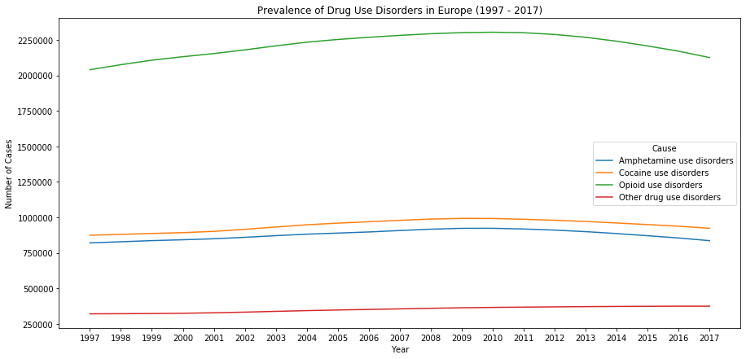

```python
# Plot overall prevalence of drug use disorders
prevalence_over_time_pivot.plot.line(figsize=(15,7),  legend=True, fontsize=10)

plt.ylabel('Number of Cases', fontsize = 10)
plt.xlabel('Year', fontsize = 10)
plt.xlim(1996, 2018)
plt.xticks(prevalence_over_time_pivot.index)
plt.title('Prevalence of Drug Use Disorders in Europe (1997 - 2017)')
plt.show()
```

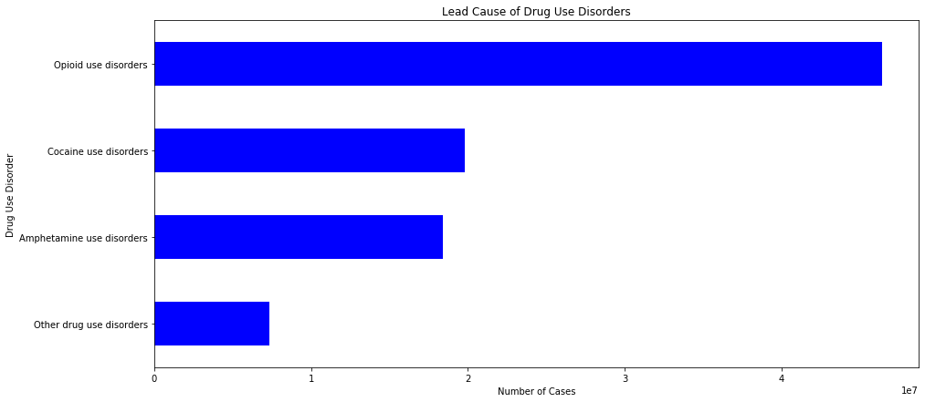

```python
# Lead cause of Drug Use Disorders
# sum the respective drug use disorders across different years to obtain total per drug use disorder
Total_drug_use_disorder = prevalence_over_time_pivot.sum(axis=0).sort_values(ascending=True)
plot_chart(Total_drug_use_disorder, 'barh', 'Drug Use Disorder', 'Number of Cases','Lead Cause of Drug Use Disorders', color='blue' )
```

From the first plot, the prevalence of the different drug use disorders remains fairly constant from 1997 to 2017, with the exception of Opioid drug use disorders, which experienced slight growth and declined. This infers that not so much has changed over the years for drug use disorders in Europe. Overall, Opioid use disorders were consistently high over the study period, with a peak between 2009 and 2010.

Furthermore, the second plot clearly visualizes number of cases recorded for different drug use disorders. As observed earlier, Opioid use disorders recorded the highest number of cases cummutatively.

### 3.1.2 Prevalence of Drug Use Disorders across European Countries

```python
# Select columns with countries, year and drug use disorders prevalence
prevalence_by_country = prevalence.loc[:, ['Country', 'Year', 'Total Cases']]
```

```python
# create prevalence of drug use disorders for given year

# set color scale
scale = [[0.0, 'rgb(223,221,228)'], [0.2, 'rgb(199,199,216)'],
         [0.4, 'rgb(169,170,201)'], [0.6, 'rgb(139,135,181)'],
         [0.8, 'rgb(98,88,158)'], [1.0, 'rgb(63,20,122)']]

# for given year, create map of europe showing prevalence
def prevalence_mapper(year):
    # preprocess to select relevant years and columns
    prevalence_by_country_plot = prevalence_by_country[prevalence_by_country['Year'] == year]
    prevalence_by_country_plot = prevalence_by_country_plot.drop('Year', axis=1)
    prevalence_by_country_plot = prevalence_by_country_plot.groupby(['Country']).sum()
    prevalence_by_country_plot = prevalence_by_country_plot.reset_index()

    # create data to plot
    mydata = [dict(type='choropleth',
                   colorscale=scale,
                   locations=prevalence_by_country_plot['Country'],
                   z=prevalence_by_country_plot['Total Cases'].astype(float),
                   locationmode='country names',
                   text=prevalence_by_country_plot['Country'],
                   hoverinfo='location+z',
                   marker=dict(line=dict(color='rgb(255,255,255)', width=2)),
                   colorbar=dict(title='Number of Cases'))]

    # convert year to str
    year = str(year)

    # create layout to plot data
    mylayout = dict(title='Prevalence of Drug Use Disorders ('+ year +')',
                    geo=dict(scope='europe',
                            showlakes=True,
                            lakecolor='rgb(95,145,237)'))

    fig = dict(data=mydata, layout=mylayout)
    return py.iplot(fig, filename='druguse_disorder')
```

```python
# show prevalence of drug use disorders 2017
prevalence_mapper(2017)
```

[interactive chart not shown]

### 3.1.3 Top 15 Countries with High Prevalence of Drug Use Disorders

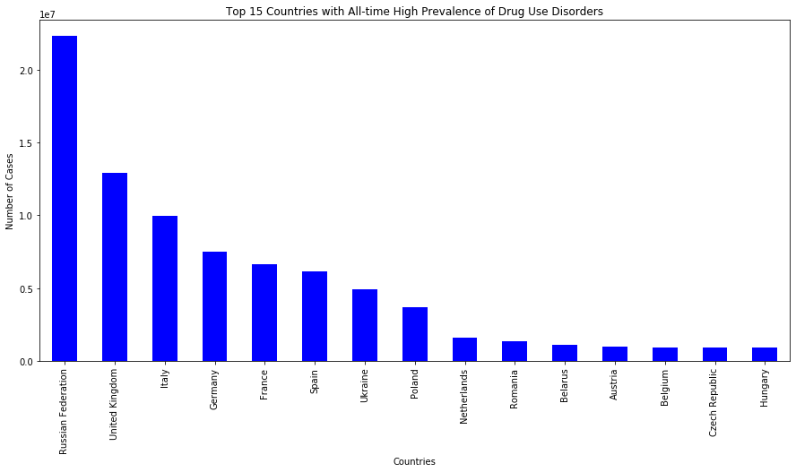

```python
# Calculate the all-time high prevalence for all countries

# copy prevalence_by_country dataframe, drop irrelevant columns and groupby countries
total_prevalence_by_country = prevalence_by_country
total_prevalence_by_country = total_prevalence_by_country.drop(['Year'], axis=1)
total_prevalence_by_country = total_prevalence_by_country.groupby('Country').sum()

# obtain top 15 countries with all time high prevalence of drug abuse orders and sort according to Total Cases
top15Countries_prevalence = total_prevalence_by_country.sort_values(by='Total Cases', ascending=False).head(15)

# plot chart of 15 top countries with all-time high prevalence of drug use disorders
plot_chart(top15Countries_prevalence, 'bar', 'Number of Cases', 'Countries','Top 15 Countries with All-time High Prevalence of Drug Use Disorders', color='blue' )
```

The above plot shows the top 15 countries with all-time high prevalence of drug use disorders. The Russian Federation sits on top with over 20 million cases recorded. This is followed by United Kingdom.

While this provides valuable insight, it may be misleading if we are concerned with recent trends since our study period spans 21 years. Also, some countries have large population compared to others. It will be interesting to how the countries fair with their respective population factored in.

For the above reasons, we will be looking at prevalence at the most recent year (2017), taking into consideration the population of these countries as at 2017

```python
# Calculate the prevalence for year 2017 (Most Recent Year) per 1000 persons
total_prevalence_2017 = prevalence_by_country

# Select records for most recent year (2017), drop irrelevant columns and groupby countries
total_prevalence_2017 = total_prevalence_2017[total_prevalence_2017['Year'] == 2017]
total_prevalence_2017 = total_prevalence_2017.drop(['Year'], axis=1)
total_prevalence_2017 = total_prevalence_2017.groupby('Country').sum()

# obtain top 15 countries with high prevalence of drug abuse orders (for 2017) and sort according to Total Cases
top15Countries_prevalence_2017 = total_prevalence_2017.sort_values(by='Total Cases', ascending=False).head(15)

# obtain population of top 15 countries with high prevalence of drug use disorders (at 2017)
# PS: all_eu_countries has been imported and cleaned earlier
top15_population_2017 = all_eu_countries[all_eu_countries['Country'].isin(top15Countries_prevalence_2017.index)]
```

```python
# reset index for top 15 Countries prevalence in 2017
top15_prevalence_2017 = top15Countries_prevalence_2017.reset_index()

# combine drug use disorders prevalence and population of top 15 countries as at 2017
top15_prevalence_pop2017 = top15_prevalence_2017.merge(top15_population_2017, on='Country')
top15_prevalence_pop2017
```

|  | Country | Total Cases | Population |
| --- | --- | --- | --- |
| 0 | Russian Federation | 876358.010351 | 144496740.0 |
| 1 | United Kingdom | 697232.636335 | 66058859.0 |
| 2 | Italy | 396237.165837 | 60536709.0 |
| 3 | Germany | 377550.283742 | 82657002.0 |
| 4 | France | 339377.950474 | 66865144.0 |
| 5 | Spain | 288105.606181 | 46593236.0 |
| 6 | Ukraine | 238671.561234 | 44831135.0 |
| 7 | Poland | 168941.450000 | 37974826.0 |
| 8 | Netherlands | 79071.286852 | 17131296.0 |
| 9 | Romania | 58662.949735 | 19587491.0 |
| 10 | Belarus | 50854.900370 | 9498264.0 |
| 11 | Czech Republic | 49298.289901 | 10594438.0 |
| 12 | Austria | 49252.564612 | 8797566.0 |
| 13 | Belgium | 47675.284585 | 11375158.0 |
| 14 | Sweden | 43833.742309 | 10057698.0 |

```python
# Caclulate per 1000 prevalence of drug use disorders for each country
top15_prevalence_pop2017 = top15_prevalence_pop2017.set_index('Country')
top15_prevalence_pop2017['Cases/1000 Persons'] = (top15_prevalence_pop2017['Total Cases'] / top15_prevalence_pop2017['Population']) * 1000
```

```python
# Select only Country and Prevalence per 1000 persons into dataframe
top15_prevalence_pop2017_plot = top15_prevalence_pop2017.drop(['Total Cases', 'Population'], axis=1)
top15_prevalence_per1000 = top15_prevalence_pop2017_plot.sort_values(by='Cases/1000 Persons', ascending=False)
```

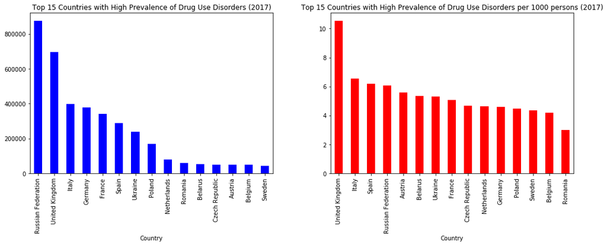

```python
# Initialise 2 columns to plot the graphs side by side
fig, axes = plt.subplots(1, 2)

# Plot the male mortality graph
top15Countries_prevalence_2017.plot.bar(legend = False, figsize = (15,6), ax=axes[0],
        title = 'Top 15 Countries with High Prevalence of Drug Use Disorders (2017)', color = 'blue')


# Plot the female mortality graph
top15_prevalence_per1000.plot.bar(legend = False, figsize = (15,6), ax=axes[1],
        title = 'Top 15 Countries with High Prevalence of Drug Use Disorders per 1000 persons (2017)', color='red')

plt.tight_layout()
plt.show()
```

The plot on the left hand side shows the Top 15 countries for 2017, with most countries still maintaining same position as before (e.g. Russian Federation and United Kingdom). However, it is interesting to see some countries have been displaced, for example, Sweden displacing Hungary.

## 3.2 Drug Use Disorders Mortality

### 3.2.1 Deaths from Drug Use Disorders (1997 to 2017)

```python
# Select relevant columns in new dataframe
mortality_over_time = mortality.loc[:, ['Cause', 'Year', 'Total Cases']]

# groupby by cause and year
mortality_over_time_by_year = mortality_over_time.groupby(['Cause', 'Year']).sum()
mortality_over_time_by_year = mortality_over_time_by_year.reset_index()

# create pivot table
mortality_over_time_pivot = mortality_over_time_by_year.pivot(index='Year', columns='Cause', values='Total Cases')
mortality_over_time_pivot.head()
```

| Cause Year | Amphetamine use disorders | Cocaine use disorders | Opioid use disorders | Other drug use disorders |
| --- | --- | --- | --- | --- |
| 1997 | 543.047871 | 750.547007 | 13663.024385 | 5533.260619 |
| 1998 | 559.672551 | 760.974739 | 13748.137738 | 5870.982990 |
| 1999 | 631.033701 | 855.877586 | 14804.388368 | 6519.067475 |
| 2000 | 696.466012 | 938.849543 | 15468.932857 | 7014.191268 |
| 2001 | 724.635441 | 947.985836 | 15237.326027 | 7202.197896 |

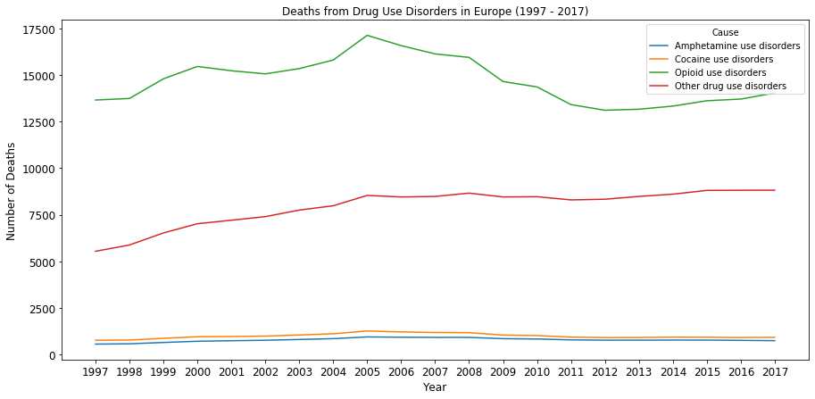

```python
# Plot overall deaths from drug use disorders over study period
mortality_over_time_pivot.plot.line(figsize=(15,7),  legend=True, fontsize=12)

plt.ylabel('Number of Deaths', fontsize = 12)
plt.xlabel('Year', fontsize = 12)
plt.xlim(1996, 2018)
plt.xticks(mortality_over_time_pivot.index)
plt.title('Deaths from Drug Use Disorders in Europe (1997 - 2017)')
plt.show()
```

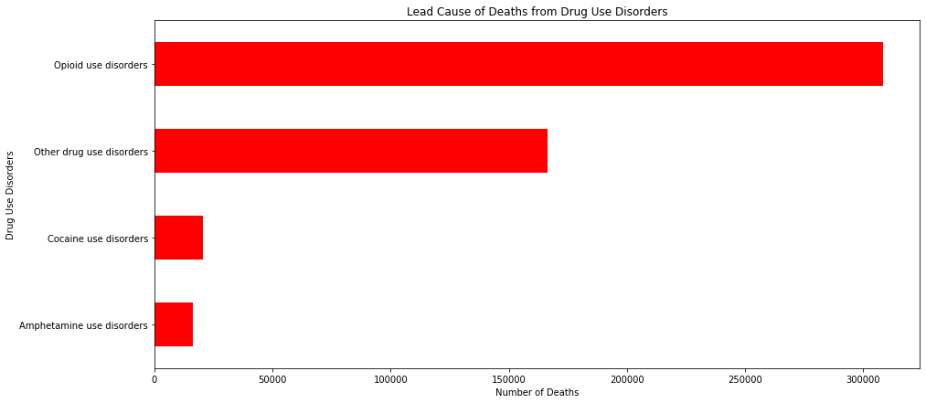

```python
# Lead cause of Drug Use Disorders
# sum the respective drug use disorders across different years to obtain total per drug use disorder
Total_death_drug_use_disorder = mortality_over_time_pivot.sum(axis=0).sort_values(ascending=True)
plot_chart(Total_death_drug_use_disorder, 'barh', 'Drug Use Disorders', 'Number of Deaths','Lead Cause of Deaths from Drug Use Disorders', color='red' )
```

It may be surprising that Other drug use disorders, which earlier had the lowest prevalence, now has considerably higher deaths than Cocaine use disorders and Amphetamine use disorders. One possible factor could be that causes classified under other drug use disorders may have more harmful substances or are more difficult to treat, hence, leading to higher mortality figures.

### 3.2.2 Deaths from Drug Use Disorders in European Countries

```python
# Obtain columns with countries, year and drug use disorders prevalence
mortality_by_country = mortality.loc[:, ['Country', 'Year', 'Total Cases']]
```

```python
# create mortality of drug use disorders for given year

# set color scale
scale = [[0.0, 'rgb(223,221,228)'], [0.2, 'rgb(199,199,216)'],
         [0.4, 'rgb(169,170,201)'], [0.6, 'rgb(139,135,181)'],
         [0.8, 'rgb(98,88,158)'], [1.0, 'rgb(63,20,122)']]

# for given year, create map of europe showing mortality
def mortality_mapper(year):
    # preprocess to select relevant years and columns
    mortality_by_country_plot = mortality_by_country[mortality_by_country['Year'] == year]
    mortality_by_country_plot = mortality_by_country_plot.drop('Year', axis=1)
    mortality_by_country_plot = mortality_by_country_plot.groupby(['Country']).sum()
    mortality_by_country_plot = mortality_by_country_plot.reset_index()

    # create data to plot
    mydata = [dict(type='choropleth',
                   colorscale=scale,
                   locations=mortality_by_country_plot['Country'],
                   z=mortality_by_country_plot['Total Cases'].astype(float),
                   locationmode='country names',
                   text=mortality_by_country_plot['Country'],
                   hoverinfo='location+z',
                   marker=dict(line=dict(color='rgb(255,255,255)', width=2)),
                   colorbar=dict(title='Number of Deaths'))]

    # convert year to string
    year = str(year)

    # create layout to plot data
    mylayout = dict(title='Deaths from Drug Use Disorders ('+ year +')',
                    geo=dict(scope='europe',
                            showlakes=True,
                            lakecolor='rgb(95,145,237)'))

    fig = dict(data=mydata, layout=mylayout)
    return py.iplot(fig, filename='drugusedisorder')
```

```python
mortality_mapper(2017)
```

[interactive chart not shown]

## 3.3 Drug Use Disorders and Age

### 3.3.1 Prevalence of Drug Use Disorders across Age Groups

```python
# Select relevant columns in new dataframe
prevalence_by_age = prevalence.loc[:, ['Age','Year', 'Total Cases']]

# groupby age groups and year
prevalence_by_age_year = prevalence_by_age.groupby(['Age', 'Year']).sum()
prevalence_by_age_year = prevalence_by_age_year.reset_index()

# create pivot table
prevalence_by_age_pivot = prevalence_by_age_year.pivot(index='Year', columns='Age', values='Total Cases')
prevalence_by_age_pivot.head()
```

| Age Year | 15-49 years | 5-14 years | 50-69 years | 70+ years |
| --- | --- | --- | --- | --- |
| 1997 | 3.398007e+06 | 3978.834087 | 518857.603433 | 132390.669144 |
| 1998 | 3.433761e+06 | 4014.971580 | 528659.124849 | 136906.926805 |
| 1999 | 3.465541e+06 | 4027.480336 | 539391.136722 | 141654.848025 |
| 2000 | 3.488855e+06 | 4013.795924 | 550293.419966 | 145831.068721 |
| 2001 | 3.517471e+06 | 3973.311079 | 559273.653914 | 150013.856743 |

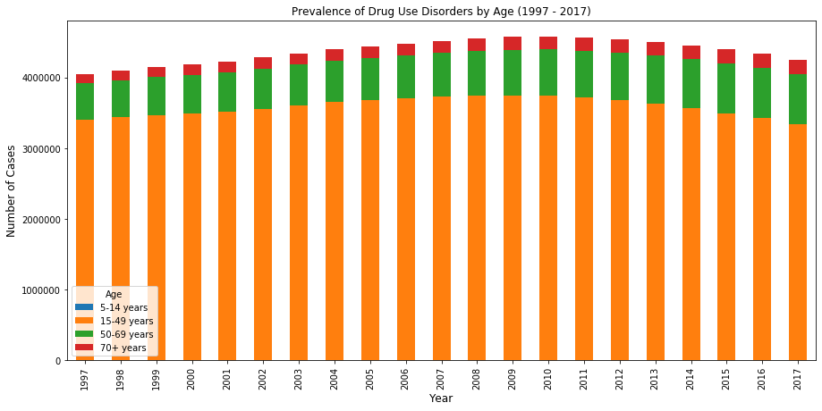

```python
# rearrange columns so that age is in ascending order
col_to_move = ['5-14 years']
cols = col_to_move + [col for col in prevalence_by_age_pivot if col not in col_to_move]
prevalence_by_age_pivot = prevalence_by_age_pivot[cols]

# plot a stacked bar chart of age groups across different years
prevalence_by_age_pivot.plot.bar(stacked=True, figsize=(15,7), legend='best')
plt.title('Prevalence of Drug Use Disorders by Age (1997 - 2017)', fontsize=12)
plt.ylabel('Number of Cases', fontsize=12)
plt.xlabel('Year', fontsize=12)
plt.show()
```

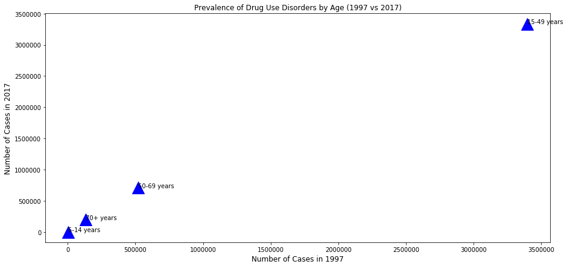

```python
# Compare drug use disorders prevalence at the beginning and end of study period for different age groups

# select drug use disorders prevalence for 1997 and 2017
prevalence_by_age_1997 = prevalence_by_age_pivot.loc[1997]
prevalence_by_age_2017 = prevalence_by_age_pivot.loc[2017]

# Create scatter plot to see if how prevalence across age groups are related at beginning and end of study period
fig = plt.figure(figsize=(15,7))
ax = fig.add_subplot(1, 1, 1)
labels = prevalence_by_age_2017.index

plt.scatter(prevalence_by_age_1997, prevalence_by_age_2017, marker='^', s=400, c='blue')
plt.title('Prevalence of Drug Use Disorders by Age (1997 vs 2017)', fontsize=12)
plt.ylabel('Number of Cases in 2017', fontsize=12)
plt.xlabel('Number of Cases in 1997', fontsize=12)

for i, txt in enumerate(labels):
    ax.annotate(txt, (prevalence_by_age_1997[i], prevalence_by_age_2017[i]))

plt.show()
```

As observed from the first plot, the number of cases recorded for first age group (5-14years) is insignficant. This is not surprising as we do not expect kids in this age range to be engaged in drugs. The largest age group (15-49years) recorded the highest cases of drug use disorders. As evident on the stacked bar chart above, this age group holds the dynamics in prevalence of drug use disorders over time.

### 3.3.2 Deaths from Drug Use Disorder across Age Groups

```python
# Select relevant columns in new dataframe
mortality_by_age = mortality.loc[:, ['Age','Year', 'Total Cases']]

# groupby age groups and year
mortality_by_age_year = mortality_by_age.groupby(['Age', 'Year']).sum()
mortality_by_age_year = mortality_by_age_year.reset_index()

# create pivot table
mortality_by_age_pivot = mortality_by_age_year.pivot(index='Year', columns='Age', values='Total Cases')
mortality_by_age_pivot.head()
```

| Age Year | 15-49 years | 5-14 years | 50-69 years | 70+ years |
| --- | --- | --- | --- | --- |
| 1997 | 14993.094714 | 10.089565 | 3832.180941 | 1654.514663 |
| 1998 | 15329.555043 | 9.976727 | 3781.994609 | 1818.241639 |
| 1999 | 16628.609932 | 10.723771 | 4094.283715 | 2076.749712 |
| 2000 | 17567.020024 | 10.674087 | 4323.045568 | 2217.700001 |
| 2001 | 17309.619056 | 10.949933 | 4465.388584 | 2326.187628 |

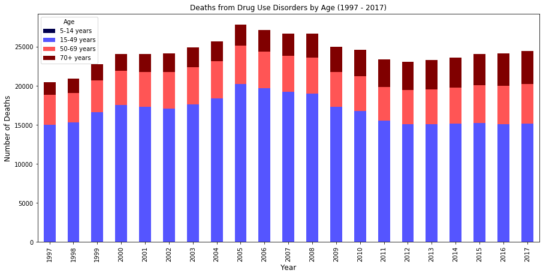

```python
# rearrange columns so that age is in ascending order
col_to_move = ['5-14 years']
cols = col_to_move + [col for col in mortality_by_age_pivot if col not in col_to_move]
mortality_by_age_pivot = mortality_by_age_pivot[cols]

# plot a stacked bar chart of age groups across different years
mortality_by_age_pivot.plot.bar(stacked=True, figsize=(15,7), legend='best', cmap='seismic')
plt.title('Deaths from Drug Use Disorders by Age (1997 - 2017)', fontsize=12)
plt.ylabel('Number of Deaths', fontsize=12)
plt.xlabel('Year', fontsize=12)
plt.show()
```

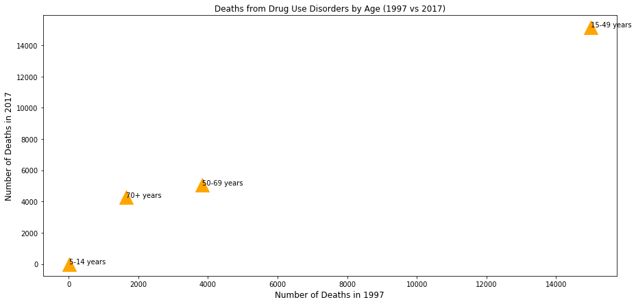

```python
# Compare drug use disorders deaths at the beginning and end of study period for different age groups

# select drug use disorders deaths for 1997 and 2017
mortality_by_age_1997 = mortality_by_age_pivot.loc[1997]
mortality_by_age_2017 = mortality_by_age_pivot.loc[2017]

# Create scatter plot to see if how death across age groups are related at beginning and end of study period
fig = plt.figure(figsize=(15,7))
ax = fig.add_subplot(1, 1, 1)
labels = mortality_by_age_2017.index

plt.scatter(mortality_by_age_1997, mortality_by_age_2017, marker='^', s=400, c='#ffa500')
plt.title('Deaths from Drug Use Disorders by Age (1997 vs 2017)', fontsize=12)
plt.ylabel('Number of Deaths in 2017', fontsize=12)
plt.xlabel('Number of Deaths in 1997', fontsize=12)

for i, txt in enumerate(labels):
    ax.annotate(txt, (mortality_by_age_1997[i], mortality_by_age_2017[i]))

plt.show()
```

A comparison of number of cases recorded at the start (1997) and end (2017) of our study period shows deaths was lower in 1997 than in 2017 across different age groups, especially in the aging population.

```python
# Transpose the pivot table created in the earlier cell
mortality_by_age_transpose = mortality_by_age_pivot.transpose()

# create pie charts to compare the percentages and absolutes deaths from drug use disorders across age groups
PiePlot(mortality_by_age_transpose, 1997, 2007, 2017, 'Comparison of Deaths from Drug Use Disorders by Age Groups')
```

[interactive chart not shown]

The reason for this cannot be ascertained from this study. It is maybe possible that, in recent years, the active population has found better ways to manage their health condition better than other age groups.

## 3.4 Drug Use Disorders and Gender

### 3.4.1 Prevalence of Drug Use Disorders across Gender

```python
# Select relevant columns in new dataframe
prevalence_by_gender = prevalence.loc[:, ['Sex','Year', 'Total Cases']]

# groupby age groups and year
prevalence_by_gender_year = prevalence_by_gender.groupby(['Sex', 'Year']).sum()
prevalence_by_gender_year = prevalence_by_gender_year.reset_index()

# create pivot table
prevalence_by_gender_pivot = prevalence_by_gender_year.pivot(index='Year', columns='Sex', values='Total Cases')
prevalence_by_gender_pivot.head()
```

| Sex Year | Female | Male |
| --- | --- | --- |
| 1997 | 1.254284e+06 | 2.798951e+06 |
| 1998 | 1.265154e+06 | 2.838188e+06 |
| 1999 | 1.275873e+06 | 2.874741e+06 |
| 2000 | 1.285257e+06 | 2.903736e+06 |
| 2001 | 1.296611e+06 | 2.934121e+06 |

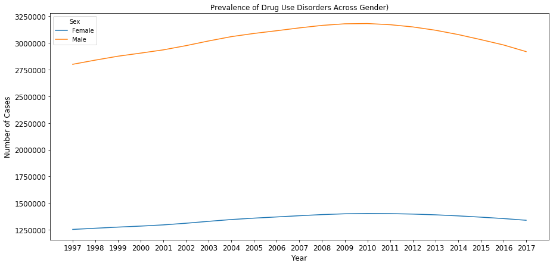

```python
# Plot overall prevalence of drug use disorders
prevalence_by_gender_pivot.plot.line(figsize=(15,7),  legend=True, fontsize=12)

plt.ylabel('Number of Cases', fontsize = 12)
plt.xlabel('Year', fontsize = 12)
plt.xlim(1996, 2018)
plt.xticks(prevalence_by_gender_pivot.index)
plt.title('Prevalence of Drug Use Disorders Across Gender)', fontsize=12)
plt.show()
```

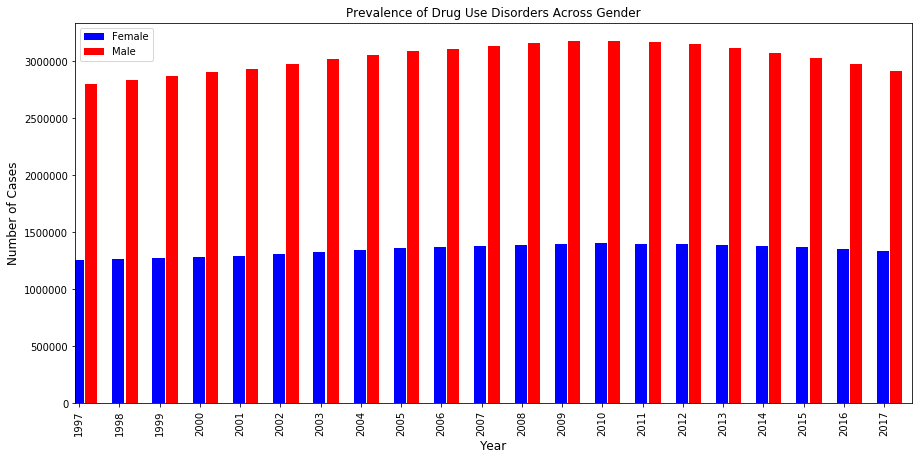

```python
# create a multiple bar plot for easy visualization
fig, ax = plt.subplots(figsize=(15,7))

prevalence_by_gender_pivot[['Female']].plot.bar(stacked=False, width=0.3, position=0.6, colormap="bwr", ax=ax)
prevalence_by_gender_pivot[['Male']].plot.bar(stacked=False, width=0.3, position=-0.5, colormap="hsv", ax=ax)
plt.legend(loc="upper left")
plt.title('Prevalence of Drug Use Disorders Across Gender', fontsize=12)
plt.ylabel('Number of Cases', fontsize=12)
plt.xlabel('Year', fontsize=12)
plt.show()
```

```python
# Transpose the pivot table created in the earlier cell
prevalence_by_gender_transpose = prevalence_by_gender_pivot.transpose()

# create pie charts to compare the percentages and absolutes prevalence from drug use disorders across gender
PiePlot(prevalence_by_gender_transpose, 1997, 2007, 2017, 'Comparison of Prevalence of Drug Use Disorders by Gender')
```

[interactive chart not shown]

Our plots shows that men have consistently had higher cases of drug use disorders over time than women. While the records of cases for women has remain fairly constant over time, men have experienced periods with higher prevalence of drug use disorders

### 3.4.2 Deaths from Drug Use Disorders across Gender

```python
# Select relevant columns in new dataframe
mortality_by_gender = mortality.loc[:, ['Sex','Year', 'Total Cases']]

# groupby age groups and year
mortality_by_gender_year = mortality_by_gender.groupby(['Sex', 'Year']).sum()
mortality_by_gender_year = mortality_by_gender_year.reset_index()

# create pivot table
mortality_by_gender_pivot = mortality_by_gender_year.pivot(index='Year', columns='Sex', values='Total Cases')
mortality_by_gender_pivot.head()
```

| Sex Year | Female | Male |
| --- | --- | --- |
| 1997 | 4538.853912 | 15951.025970 |
| 1998 | 4668.300487 | 16271.467532 |
| 1999 | 5100.918896 | 17709.448234 |
| 2000 | 5353.014960 | 18765.424720 |
| 2001 | 5496.105243 | 18616.039957 |

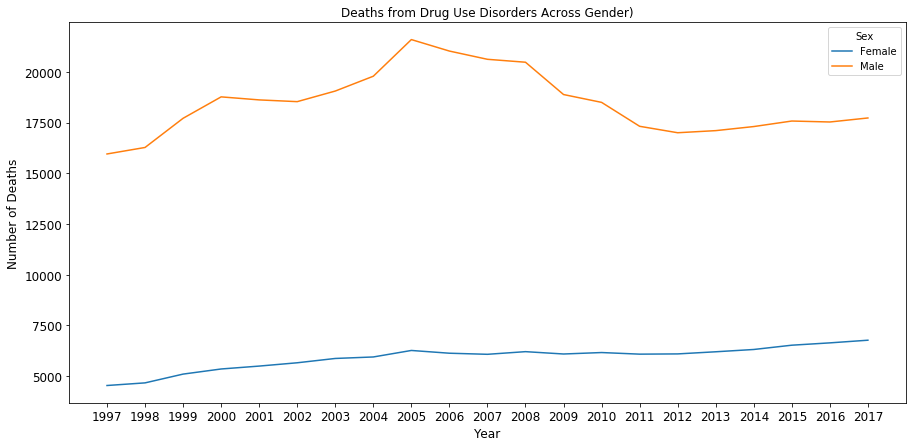

```python
# Plot overall prevalence of drug use disorders
mortality_by_gender_pivot.plot.line(figsize=(15,7), legend=True, fontsize=12)

plt.ylabel('Number of Deaths', fontsize = 12)
plt.xlabel('Year', fontsize = 12)
plt.xlim(1996, 2018)
plt.xticks(mortality_by_gender_pivot.index)
plt.title('Deaths from Drug Use Disorders Across Gender)', fontsize=12)
plt.show()
```

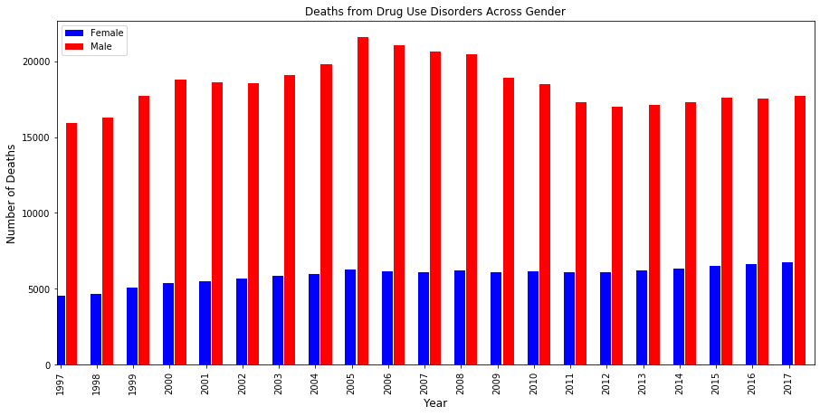

```python
# create a multiple bar plot for easy visualization
fig, ax = plt.subplots(figsize=(15,7))

mortality_by_gender_pivot[['Female']].plot.bar(stacked=False, width=0.3, position=0.6, colormap="bwr", ax=ax)
mortality_by_gender_pivot[['Male']].plot.bar(stacked=False, width=0.3, position=-0.5, colormap="hsv", ax=ax)
plt.legend(loc="upper left")
plt.title('Deaths from Drug Use Disorders Across Gender', fontsize=12)
plt.ylabel('Number of Deaths', fontsize=12)
plt.xlabel('Year', fontsize=12)
plt.show()
```

```python
# Transpose the pivot table created in the earlier cell
mortality_by_gender_transpose = mortality_by_gender_pivot.transpose()

# create pie charts to compare the percentages and absolutes deaths from drug use disorders across gender
PiePlot(mortality_by_gender_transpose, 1997, 2007, 2017, 'Comparison of Deaths from Drug Use Disorders by Gender')
```

[interactive chart not shown]

Again, our plots shows that men have consistently had higher deaths from drug use disorders over time than women. However, female mortality from drug use disorders has been on a rise slightly as can be visualized from our multiple bar charts.

## 3.4 Specific Drugs Use Disorders Summary Statistics

```python
def summary_disorder(drug_use_disorder, measure):
    """
        Compute summary statistics for drug use disorder

        Parameters
        ----------

        drug_use_disorder: specific drug use disorders analyzed in earlier sections

        measure: prevalence or death

        Returns
        ---------
        Dictionary of summary statistics for specified drug use disorder
    """
    # create a dictionary to store all summary
    summary = {}

    # select metric to work with based on parameter passed in
    if measure == 'prevalence':
        df = prevalence
    elif measure == 'mortality':
        df = mortality

    # subset specific drug use disorder based on parameter passed in
    df_disorder = df[df['Cause'] == drug_use_disorder]

# calculate disorder cummulative annual growth for the study period
    # create empty list to store intial and final values of total cases
    init_final_value = []

    # select appropriate columns, group by year and sum to obtain total annually
    df_disorder_by_year = df_disorder[['Year', 'Total Cases']]
    df_disorder_by_year = df_disorder_by_year.groupby('Year').sum()

    # save the values from the first and last year of study period
    init_final_value.append(df_disorder_by_year.iloc[0].values)
    init_final_value.append(df_disorder_by_year.iloc[-1].values)

    # calculate percent change annually
    df_disorder_by_year['Percent'] = df_disorder_by_year.pct_change()

    # calculate the sum of the dataframe across rows, selecting the percent column as cummulative annual growth in drug use disorder
    df_disorder_cummulative = df_disorder_by_year.sum(axis=0)['Percent']
    df_disorder_cummulative = df_disorder_cummulative * 100


# obtain male to female ratio for specified disorder
    # select appropriate columns
    df_disorder_gender_ratio = df_disorder[['Sex', 'Total Cases']]

    #group by gender and sum to obtain total per gender
    df_disorder_gender_ratio = df_disorder_gender_ratio.groupby('Sex').sum().sort_values(by='Sex',ascending=False)

    # create column, calculate ratio per gender and store to
    df_disorder_gender_ratio['Ratio'] = df_disorder_gender_ratio[['Total Cases']]/df_disorder_gender_ratio['Total Cases'].sum(axis=0)
    gender_ratio = df_disorder_gender_ratio['Ratio'].tolist()

# Finally, insert all results in the summary dictionary
    summary['Drug Use Disorder'] = drug_use_disorder
    summary['Inital_Year_Val'] = int(init_final_value[0])
    summary['Final_Year_Val'] = int(init_final_value[1])
    summary['Cummulative_Annual_Growth(%)'] = round(df_disorder_cummulative, 2)
    #summary['Top5Countries'] = top5_countries.values
    summary['Male_Percent'] = round(gender_ratio[0] * 100, 2)
    summary['Female_Percent'] = round(gender_ratio[1] * 100, 2)

    summary = pd.DataFrame.from_dict(summary, orient='index')
    summary.columns = [measure.title()]
    summary.index.name = 'Stat'
    return summary
```

### 3.4.1 Opioid Use Disorders

```python
# merge opioid use disorders prevalence and mortality on the index
summary_disorder('Opioid use disorders', 'prevalence').merge(summary_disorder('Opioid use disorders', 'mortality'), on='Stat')
```

| Stat | Prevalence | Mortality |
| --- | --- | --- |
| Drug Use Disorder | Opioid use disorders | Opioid use disorders |
| Inital_Year_Val | 2039742 | 13663 |
| Final_Year_Val | 2125186 | 14044 |
| Cummulative_Annual_Growth(%) | 4.23 | 4.33 |
| Male_Percent | 71.71 | 80.21 |
| Female_Percent | 28.29 | 19.79 |

### 3.4.2 Cocaine Use Disorders

```python
# merge cocaine use disorders prevalence and mortality on the index
summary_disorder('Cocaine use disorders', 'prevalence').merge(summary_disorder('Cocaine use disorders', 'mortality'), on='Stat')
```

| Stat | Prevalence | Mortality |
| --- | --- | --- |
| Drug Use Disorder | Cocaine use disorders | Cocaine use disorders |
| Inital_Year_Val | 873618 | 750 |
| Final_Year_Val | 922844 | 907 |
| Cummulative_Annual_Growth(%) | 5.6 | 22.74 |
| Male_Percent | 72.59 | 83.89 |
| Female_Percent | 27.41 | 16.11 |

### 3.4.3 Amphetamine Use Disorders

```python
# merge Amphetamine use disorders prevalence and mortality on the index
summary_disorder('Amphetamine use disorders', 'prevalence').merge(summary_disorder('Amphetamine use disorders', 'mortality'), on='Stat')
```

| Stat | Prevalence | Mortality |
| --- | --- | --- |
| Drug Use Disorder | Amphetamine use disorders | Amphetamine use disorders |
| Inital_Year_Val | 819718 | 543 |
| Final_Year_Val | 835287 | 728 |
| Cummulative_Annual_Growth(%) | 2.02 | 32.29 |
| Male_Percent | 65.85 | 78.86 |
| Female_Percent | 34.15 | 21.14 |

### 3.4.4 Other drug use disorders

```python
# merge Other drug use disorders prevalence and mortality on the index
summary_disorder('Other drug use disorders', 'prevalence').merge(summary_disorder('Other drug use disorders', 'mortality'), on='Stat')
```

| Stat | Prevalence | Mortality |
| --- | --- | --- |
| Drug Use Disorder | Other drug use disorders | Other drug use disorders |
| Inital_Year_Val | 320154 | 5533 |
| Final_Year_Val | 374122 | 8816 |
| Cummulative_Annual_Growth(%) | 15.66 | 48.2 |
| Male_Percent | 53.06 | 66.08 |
| Female_Percent | 46.94 | 33.92 |

We observed only Opioids use disorders experienced similar cummulative annual growth rate between its prevalence and mortality. This tells us that for our study period, the rate at which number of cases for opioid use disorders were recorded is almost the same as the rate at which deaths for opioids use disorders were recorded for the same period. However, it is important to note that this does not translate to cases recorded in absolute values.

Furthermore, across all drug use disorders, men have a higher percentage (both prevalence and mortality) than women.

# 4.0 Predictions

From our observations, trends and plots so far, we can make a few predictions especially considering the trends in the last six years.

Prevalence of drug use disorders will continue to experience retarded growth as it has consistently experienced in the last six years. While it is still a major issue, I believe more persons are becoming more aware of the dangers of illict drug use and how it affects mental health. I also believe this will have an effect of bringing the mortality from drug use disorders to a negative growth in the coming years

Across age groups, I believe the trend will continue where people within the active population (15 - 49years) will have reduced deaths as a result of awareness on treatment of drug use disorders. It may be difficult to convince someone who is already aged (70+ years) and addicted to drugs, to change their lifestyle completely as most may see that there have almost approach the end of their lives.

# 5.0 Conclusion

In general, the prevalence of drug use disorders is experiencing a gradual decrease in recent time (2010 - 2017). However, the same cannot be said with certainty for mortality as this tends to differ across different drug use disorders.

United Kingdom, Russia Federation and Italy have high prevalence of drug use disorders. It is important for the relevant authorities to be aware of these findings to ensure that appropriate actions are being taken to address them.

I recommend policy makers and health practitioners to focus on solutions that will solve some of the problems and findings identified from this analysis. Solutions may include restricted access or ban on some of these drugs which, when consumed in unprecedented amounts, can lead to drug use disorders (for example, opioids). Also, engaging top brands and awareness creation of these facts identified may help those living in the shadows to be in a better position to help themselves and go for treatment.

## References

World Health Organization https://www.who.int/topics/substance_abuse/en/

Our World in Data https://ourworldindata.org/mental-health